# Koca_ps1.Rmd

Ilayda Koca

Due Date: 2022/09/11 @ 6PM CST

## Assignment 1

## Question 1 [1 point]

*Require `tidyverse` and load the `sc_debt.Rds` data by assigning it to an object named `df`.*

```r
require(tidyverse)
df <- readRDS("../data/sc_debt.Rds")
```

## Question 2 [2 points]

*Which school has the lowest admission rate?*

```r
df%>%
  filter(adm_rate > 0) %>%
  arrange(adm_rate) %>%
  select(instnm,adm_rate)
```

```
## # A tibble: 1,586 × 2
##    instnm                                      adm_rate
##    <chr>                                          <dbl>
##  1 Hampshire College                             0.0197
##  2 Curtis Institute of Music                     0.0393
##  3 Stanford University                           0.0434
##  4 Harvard University                            0.0464
##  5 Pacific Oaks College                          0.0511
##  6 Columbia University in the City of New York   0.0545
##  7 Princeton University                          0.0578
##  8 Yale University                               0.0608
##  9 University of Chicago                         0.0617
## 10 California Institute of Technology            0.0642
## # … with 1,576 more rows
```

> - Hampshire College

## Question 3 [2 points]

*Which are the top 10 schools by average SAT score?*

```r
df%>%
  arrange(-sat_avg) %>%
  select(instnm,sat_avg)
```

```
## # A tibble: 2,546 × 2
##    instnm                                 sat_avg
##    <chr>                                    <int>
##  1 California Institute of Technology        1557
##  2 Massachusetts Institute of Technology     1547
##  3 University of Chicago                     1528
##  4 Harvey Mudd College                       1526
##  5 Duke University                           1522
##  6 Franklin W Olin College of Engineering    1522
##  7 Washington University in St Louis         1520
##  8 Rice University                           1520
##  9 Yale University                           1517
## 10 Harvard University                        1517
## # … with 2,536 more rows
```

## Question 4 [2 points]

*Which state is home to the school with the largest median earnings of recent graduates, and how much did they make?*

```r
df%>%
  arrange(-md_earn_wne_p6) %>%
  select(instnm,stabbr,md_earn_wne_p6)
```

```
## # A tibble: 2,546 × 3
##    instnm                                                       stabbr md_earn…¹
##    <chr>                                                        <chr>      <int>
##  1 University of Health Sciences and Pharmacy in St. Louis      MO        120400
##  2 Albany College of Pharmacy and Health Sciences               NY        112100
##  3 Samuel Merritt University                                    CA        100100
##  4 Massachusetts Institute of Technology                        MA         82200
##  5 Oregon Health & Science University                           OR         80000
##  6 Louisiana State University Health Sciences Center-Shreveport LA         78200
##  7 Cochran School of Nursing                                    NY         77300
##  8 Duke University                                              NC         76300
##  9 MCPHS University                                             MA         75700
## 10 Los Angeles County College of Nursing and Allied Health      CA         75300
## # … with 2,536 more rows, and abbreviated variable name ¹md_earn_wne_p6
```

> - MO (Missouri), 120400 dollars a year.

## Question 5 [2 points]

*What is the average SAT score of the school with the highest median earnings identified in question 4?*

```r
df%>%
  filter(str_detect(instnm,"Pharmacy in St. Louis")) %>%
  arrange(-md_earn_wne_p6) %>%
  select(instnm,sat_avg)
```

```
## # A tibble: 1 × 2
##   instnm                                                  sat_avg
##   <chr>                                                     <int>
## 1 University of Health Sciences and Pharmacy in St. Louis    1262
```

> - 1262

## Question 6 [2 points]

*Calculate the average SAT score and median earnings of recent graduates by state.*

```r
df %>%
group_by(stabbr)  %>%
summarise(average_sat = mean(sat_avg,na.rm=T),median_earnings = mean(md_earn_wne_p6,na.rm=T))
```

```
## # A tibble: 51 × 3
##    stabbr average_sat median_earnings
##    <chr>        <dbl>           <dbl>
##  1 AK           1121           33300
##  2 AL           1123.          28082.
##  3 AR           1141.          30452.
##  4 AZ           1147.          27613.
##  5 CA           1183.          33017.
##  6 CO           1132.          33955.
##  7 CT           1194.          35994.
##  8 DC           1262           41325
##  9 DE           1043           32443.
## 10 FL           1142.          30318.
## # … with 41 more rows
```

## Question 7 [2 points]

*Plot the average SAT score (x-axis) against the median earnings of recent graduates (y-axis) by school.*

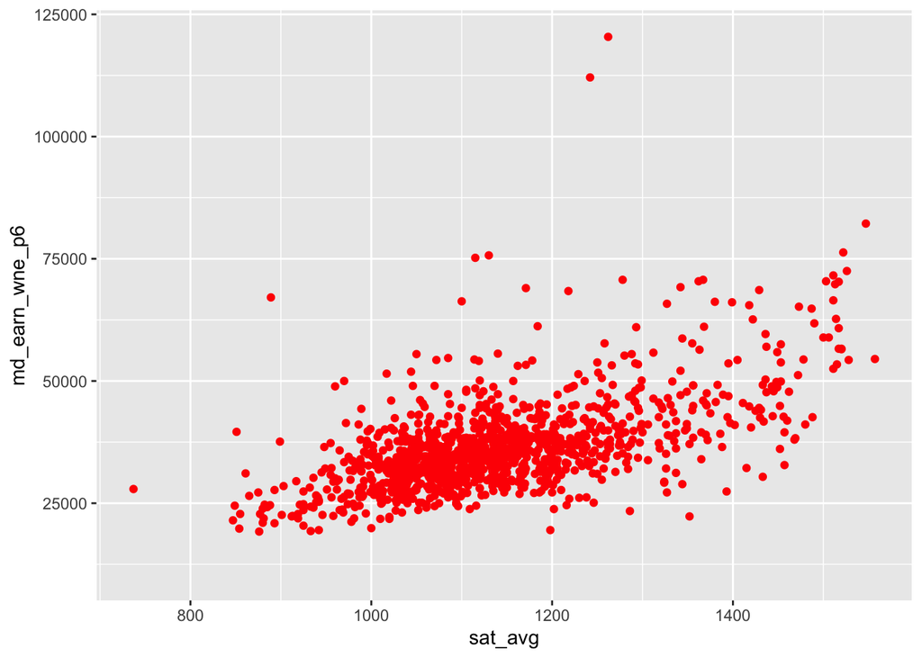

```r
df %>%
  ggplot(aes(x = sat_avg,y = md_earn_wne_p6)) + geom_point(color = 'red')
```

## Question 8 [4 points]

*Plot the average SAT score (x-axis) against the median earnings of recent graduates (y-axis) by **STATE**. (Extra credit: plot the line of best fit.)*

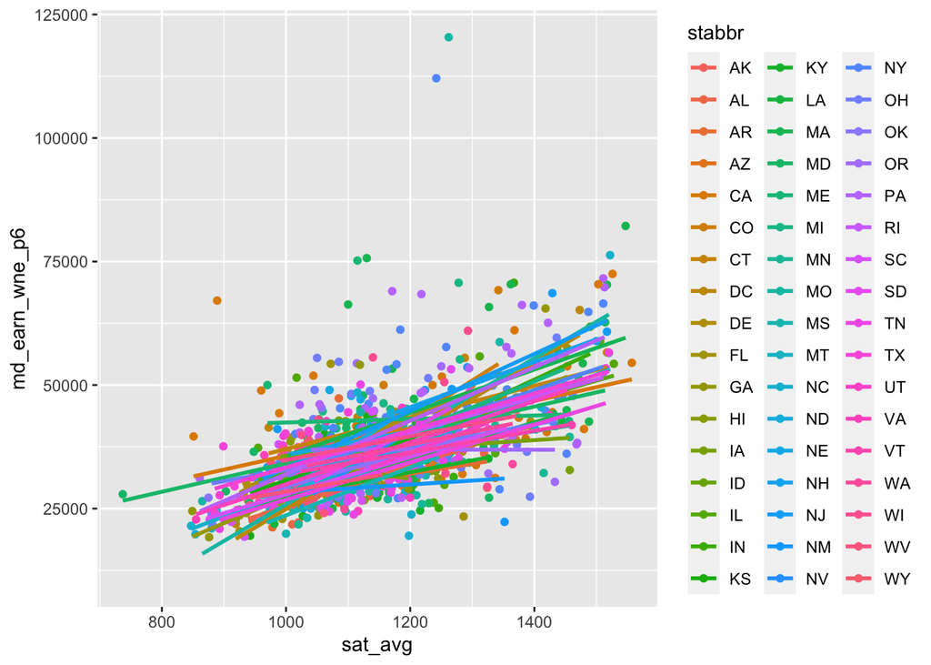

```r
df %>%
  ggplot(aes(x = sat_avg,y = md_earn_wne_p6, color = stabbr)) +
  geom_point() +
  geom_smooth(method = 'lm',se = F)
```

## Question 9 [4 points]

*What relationship do you observe? Why do you think this relationship exists?*

> - The best fit lines to the data in the “median earnings of recent grads vs average sat” graph have positive slope, suggesting that there is a positive correlation between median earnings of recent grads and average sat scores of students. This relationship might exist because students who score higher in high school level exams, including the SAT, also do better in college classes, scoring higher GPA, and therefore get higher paying jobs. Although there is a positive correlation, we can not deduce a causation relationship, such as “scoring higher in the SAT results in higher future earning.”